# DATASCI 506 - Problem Set 3

Author

Jiahao Li

GitHub Repository: https://github.com/epter-png/data506-ps03

## Problem 1 - NHANES Audiometry

### (a) Import and merge data

```r
library(foreign)

aux <- read.xport("data/AUX_I.xpt")
demo <- read.xport("data/DEMO_I.xpt")

nhanes <- merge(aux, demo, by = "SEQN", all = FALSE)

dim(nhanes)
```

```
[1] 4582  119
```

The two datasets are merged by the respondent identifier SEQN. Only respondents appearing in both datasets are retained. The merged dataset contains 4,582 observations and 119 variables.

### (b) Clean variables

```r
nhanes$gender <- factor(
  nhanes$RIAGENDR,
  levels = c(1, 2),
  labels = c("Male", "Female")
)

nhanes$citizenship <- factor(
  nhanes$DMDCITZN,
  levels = c(1, 2),
  labels = c("US citizen", "Not US citizen")
)

table(nhanes$gender, useNA = "ifany")
```

```
  Male Female
  2176   2406
```

```r
table(nhanes$citizenship, useNA = "ifany")
```

```
    US citizen Not US citizen           <NA>
          3684            884             14
```

Gender and citizenship are converted to labeled factors. Refused and unknown citizenship responses are treated as missing.

```r
nhanes$children <- nhanes$DMDHHSZA

nhanes$children[!nhanes$children %in% 0:3] <- NA

table(nhanes$children, useNA = "ifany")
```

```
   0    1    2    3
3463  737  317   65
```

The number of children aged five or younger is kept numeric, with 3 representing three or more children.

```r
income_codes <- c(1:10, 14, 15)

income_labels <- c(
  "$0-4,999",
  "$5,000-9,999",
  "$10,000-14,999",
  "$15,000-19,999",
  "$20,000-24,999",
  "$25,000-34,999",
  "$35,000-44,999",
  "$45,000-54,999",
  "$55,000-64,999",
  "$65,000-74,999",
  "$75,000-99,999",
  "$100,000+"
)

nhanes$income_category <- factor(
  nhanes$INDHHIN2,
  levels = c(income_codes, 12, 13),
  labels = c(
    income_labels,
    "$20,000+ (broad category)",
    "Under $20,000 (broad category)"
  )
)

nhanes$income_score <- match(
  nhanes$INDHHIN2,
  income_codes
)

table(nhanes$income_category, useNA = "ifany")
```

```
                      $0-4,999                   $5,000-9,999
                           101                            146
                $10,000-14,999                 $15,000-19,999
                           233                            262
                $20,000-24,999                 $25,000-34,999
                           272                            461
                $35,000-44,999                 $45,000-54,999
                           439                            381
                $55,000-64,999                 $65,000-74,999
                           295                            244
                $75,000-99,999                      $100,000+
                           458                            795
     $20,000+ (broad category) Under $20,000 (broad category)
                           145                             53
                          <NA>
                           297
```

```r
table(nhanes$income_score, useNA = "ifany")
```

```
   1    2    3    4    5    6    7    8    9   10   11   12 <NA>
 101  146  233  262  272  461  439  381  295  244  458  795  495
```

Income codes 14 and 15 represent the highest brackets, so the twelve nonoverlapping brackets are scored from 1 to 12 in increasing income order. Codes 12 and 13 describe overlapping ranges; they are retained as labeled categories but excluded from the numeric score. Refused and unknown responses are treated as missing.

### (c) Poisson regression models

```r
for (v in c("AUXTWIDR", "AUXTWIDL")) {
  nhanes[[v]][nhanes[[v]] %in% c(555, 777, 888)] <- NA
}

model_1R <- glm(
  AUXTWIDR ~ gender,
  data = nhanes,
  family = poisson(link = "log")
)

model_2R <- glm(
  AUXTWIDR ~ gender + citizenship + children + income_score,
  data = nhanes,
  family = poisson(link = "log")
)

model_1L <- glm(
  AUXTWIDL ~ gender,
  data = nhanes,
  family = poisson(link = "log")
)

model_2L <- glm(
  AUXTWIDL ~ gender + citizenship + children + income_score,
  data = nhanes,
  family = poisson(link = "log")
)

models <- list(
  "1R" = model_1R,
  "2R" = model_2R,
  "1L" = model_1L,
  "2L" = model_2L
)
```

```r
# Extract IRRs from a fitted Poisson model.
# Inputs: model and model name. Output: coefficient IRR table.
get_irr <- function(model, model_name) {
  data.frame(
    Model = model_name,
    Term = names(coef(model)),
    IRR = exp(unname(coef(model)))
  )
}

irr_results <- do.call(
  rbind,
  lapply(names(models), function(name) {
    get_irr(models[[name]], name)
  })
)

knitr::kable(
  irr_results,
  digits = 4,
  row.names = FALSE,
  caption = "Exponentiated coefficients for the four Poisson models"
)
```

Exponentiated coefficients for the four Poisson models

| Model | Term | IRR |
| --- | --- | --- |
| 1R | (Intercept) | 84.3174 |
| 1R | genderFemale | 1.0093 |
| 2R | (Intercept) | 88.4374 |
| 2R | genderFemale | 1.0150 |
| 2R | citizenshipNot US citizen | 1.0469 |
| 2R | children | 0.9944 |
| 2R | income_score | 0.9921 |
| 1L | (Intercept) | 84.7584 |
| 1L | genderFemale | 1.0130 |
| 2L | (Intercept) | 88.8213 |
| 2L | genderFemale | 1.0187 |
| 2L | citizenshipNot US citizen | 1.0218 |
| 2L | children | 0.9830 |
| 2L | income_score | 0.9935 |

Exponentiated slope coefficients represent ratios of expected tympanometric widths, holding other covariates fixed. The exponentiated intercept is the baseline expected width.

```r
# Summarize sample size and model fit.
# Input: fitted Poisson model and model name.
# Output: one-row data frame of N, McFadden pseudo-R2, and AIC.
get_model_stats <- function(model, model_name) {
  y <- model.response(model.frame(model))

  null_model <- glm(
    y ~ 1,
    family = poisson(link = "log")
  )

  data.frame(
    Model = model_name,
    N = nobs(model),
    McFadden_R2 = 1 -
      as.numeric(logLik(model)) / as.numeric(logLik(null_model)),
    AIC = AIC(model)
  )
}

model_stats <- do.call(
  rbind,
  lapply(names(models), function(name) {
    get_model_stats(models[[name]], name)
  })
)

knitr::kable(
  model_stats,
  digits = 4,
  row.names = FALSE,
  caption = "Sample sizes and model fit statistics"
)
```

Sample sizes and model fit statistics

| Model | N | McFadden_R2 | AIC |
| --- | --- | --- | --- |
| 1R | 4149 | 0.0001 | 96618.48 |
| 2R | 3705 | 0.0042 | 84916.04 |
| 1L | 4103 | 0.0001 | 98685.15 |
| 2L | 3665 | 0.0027 | 86597.96 |

McFadden’s pseudo-R-squared is calculated as $1 - \ell_{\text{model}}/\ell_{\text{null}}$. Each null model uses the same observations as its corresponding fitted model.

### (d) Gender comparison in model 2L

```r
gender_result <- summary(model_2L)$coefficients["genderFemale", ]

gender_result
```

```
    Estimate   Std. Error      z value     Pr(>|z|)
1.857273e-02 3.599573e-03 5.159705e+00 2.473393e-07
```

```r
exp(coef(model_2L)["genderFemale"])
```

```
genderFemale
    1.018746
```

I tested whether the female-to-male IRR equals 1. The estimated IRR is 1.0187 (z = 5.160, p = 2.47e-7), so I reject the null hypothesis at the 5% level under the Poisson model. Holding citizenship, number of young children, and income score fixed, the expected left-ear tympanometric width is about 1.87% higher for females than for males.

```r
comparison <- data.frame(
  gender = factor(c("Male", "Female"), levels = levels(nhanes$gender)),
  citizenship = factor(
    rep("US citizen", 2),
    levels = levels(nhanes$citizenship)
  ),
  children = 0,
  income_score = 6
)

comparison$predicted_width <- predict(
  model_2L,
  newdata = comparison,
  type = "response"
)

knitr::kable(comparison, digits = 3, row.names = FALSE)
```

| gender | citizenship | children | income_score | predicted_width |
| --- | --- | --- | --- | --- |
| Male | US citizen | 0 | 6 | 85.397 |
| Female | US citizen | 0 | 6 | 86.998 |

For US citizens with no children aged five or younger and an income score of 6 ($25,000–34,999), the predicted widths are 85.397 for males and 86.998 for females, a difference of about 1.601. Because the model has no gender interactions, equal predicted means correspond to an IRR of 1. The same Wald test therefore provides evidence of a difference in predicted means under the Poisson model (p = 2.47e-7).

## Problem 2 - Sakila

```r
library(DBI)
library(RSQLite)
library(microbenchmark)

con <- dbConnect(
  SQLite(),
  "data/sakila_master.db"
)

dbListTables(con)
```

```
 [1] "actor"                  "address"                "category"
 [4] "city"                   "country"                "customer"
 [7] "customer_list"          "film"                   "film_actor"
[10] "film_category"          "film_list"              "film_text"
[13] "inventory"              "language"               "payment"
[16] "rental"                 "sales_by_film_category" "sales_by_store"
[19] "staff"                  "staff_list"             "store"
```

### (a) Customers by store

```r
# Extract customer records and summarize them in R.
# Input: open database connection.
# Output: customer count and active percentage for each store.
customers_R <- function(con) {
  customers <- dbGetQuery(
    con,
    "SELECT store_id, active FROM customer"
  )

  groups <- split(customers, customers$store_id)

  do.call(rbind, lapply(groups, function(x) {
    data.frame(
      store_id = x$store_id[1],
      customers = nrow(x),
      active_percent = 100 * mean(x$active == 1)
    )
  }))
}

answer_a_R <- customers_R(con)

knitr::kable(
  answer_a_R,
  digits = 2,
  row.names = FALSE,
  caption = "Customer summary using SQL extraction and R"
)
```

Customer summary using SQL extraction and R

| store_id | customers | active_percent |
| --- | --- | --- |
| 1 | 326 | 97.55 |
| 2 | 273 | 97.44 |

```r
sql_a <- "
  SELECT store_id,
         COUNT(*) AS customers,
         100.0 * AVG(active) AS active_percent
  FROM customer
  GROUP BY store_id
  ORDER BY store_id
"

answer_a_SQL <- dbGetQuery(con, sql_a)

knitr::kable(
  answer_a_SQL,
  digits = 2,
  row.names = FALSE,
  caption = "Customer summary using a single SQL query"
)
```

Customer summary using a single SQL query

| store_id | customers | active_percent |
| --- | --- | --- |
| 1 | 326 | 97.55 |
| 2 | 273 | 97.44 |

```r
benchmark_a <- microbenchmark(
  R = customers_R(con),
  SQL = dbGetQuery(con, sql_a),
  times = 30L
)

knitr::kable(
  summary(benchmark_a, unit = "ms"),
  digits = 3,
  row.names = FALSE,
  caption = "Execution times in milliseconds"
)
```

Execution times in milliseconds

| expr | min | lq | mean | median | uq | max | neval |
| --- | --- | --- | --- | --- | --- | --- | --- |
| R | 0.878 | 0.913 | 1.063 | 0.931 | 0.962 | 4.019 | 30 |
| SQL | 0.424 | 0.460 | 0.503 | 0.479 | 0.494 | 0.748 | 30 |

Both methods give the same results. Store 1 has 326 customers, of whom 97.55% are active, while Store 2 has 273 customers, of whom 97.44% are active. In this benchmark, the single SQL query has a lower median execution time than extracting the data and calculating the results in R.

### (b) Staff names and countries

```r
# Extract and join staff location tables in R.
# Input: open database connection.
# Output: staff names and countries, ordered by staff ID.
staff_R <- function(con) {
  staff <- dbGetQuery(
    con,
    "SELECT staff_id, first_name, last_name, address_id FROM staff"
  )
  address <- dbGetQuery(
    con,
    "SELECT address_id, city_id FROM address"
  )
  city <- dbGetQuery(
    con,
    "SELECT city_id, country_id FROM city"
  )
  country <- dbGetQuery(
    con,
    "SELECT country_id, country FROM country"
  )

  result <- merge(staff, address, by = "address_id")
  result <- merge(result, city, by = "city_id")
  result <- merge(result, country, by = "country_id")

  result <- result[order(result$staff_id), ]
  result[c("staff_id", "first_name", "last_name", "country")]
}

answer_b_R <- staff_R(con)

knitr::kable(answer_b_R, row.names = FALSE)
```

| staff_id | first_name | last_name | country |
| --- | --- | --- | --- |
| 1 | Mike | Hillyer | Canada |
| 2 | Jon | Stephens | Australia |

```r
sql_b <- "
  SELECT s.staff_id, s.first_name, s.last_name, co.country
  FROM staff AS s
  JOIN address AS a ON s.address_id = a.address_id
  JOIN city AS ci ON a.city_id = ci.city_id
  JOIN country AS co ON ci.country_id = co.country_id
  ORDER BY s.staff_id
"

answer_b_SQL <- dbGetQuery(con, sql_b)

knitr::kable(answer_b_SQL, row.names = FALSE)
```

| staff_id | first_name | last_name | country |
| --- | --- | --- | --- |
| 1 | Mike | Hillyer | Canada |
| 2 | Jon | Stephens | Australia |

```r
benchmark_b <- microbenchmark(
  R = staff_R(con),
  SQL = dbGetQuery(con, sql_b),
  times = 30L
)

knitr::kable(
  summary(benchmark_b, unit = "ms"),
  digits = 3,
  row.names = FALSE,
  caption = "Execution times in milliseconds"
)
```

Execution times in milliseconds

| expr | min | lq | mean | median | uq | max | neval |
| --- | --- | --- | --- | --- | --- | --- | --- |
| R | 2.333 | 2.432 | 2.566 | 2.531 | 2.671 | 3.122 | 30 |
| SQL | 0.392 | 0.431 | 0.457 | 0.447 | 0.471 | 0.617 | 30 |

Both methods identify Mike Hillyer in Canada and Jon Stephens in Australia. The single SQL query has a lower median execution time than extracting the four tables and joining them in R.

### (c) Films with the highest total rental revenue

```r
# Calculate total payments per film using R.
# Input: open database connection.
# Output: film(s) tied for the highest total rental revenue.
revenue_R <- function(con) {
  payment <- dbGetQuery(
    con, "SELECT rental_id, amount FROM payment"
  )
  rental <- dbGetQuery(
    con, "SELECT rental_id, inventory_id FROM rental"
  )
  inventory <- dbGetQuery(
    con, "SELECT inventory_id, film_id FROM inventory"
  )
  film <- dbGetQuery(
    con, "SELECT film_id, title FROM film"
  )

  result <- merge(payment, rental, by = "rental_id")
  result <- merge(result, inventory, by = "inventory_id")
  result <- merge(result, film, by = "film_id")

  result$cents <- round(100 * result$amount)
  totals <- aggregate(cents ~ film_id + title, result, sum)

  highest <- totals[totals$cents == max(totals$cents), ]
  highest$total_revenue <- highest$cents / 100

  highest <- highest[order(highest$film_id), ]
  highest[c("film_id", "title", "total_revenue")]
}

answer_c_R <- revenue_R(con)

knitr::kable(
  answer_c_R,
  digits = 2,
  row.names = FALSE,
  caption = "Films with the highest total rental revenue (USD)"
)
```

Films with the highest total rental revenue (USD)

| film_id | title | total_revenue |
| --- | --- | --- |
| 879 | TELEGRAPH VOYAGE | 231.73 |

```r
sql_c <- "
  WITH revenue AS (
    SELECT f.film_id, f.title,
           SUM(CAST(ROUND(100 * p.amount) AS INTEGER)) AS cents
    FROM payment AS p
    JOIN rental AS r ON p.rental_id = r.rental_id
    JOIN inventory AS i ON r.inventory_id = i.inventory_id
    JOIN film AS f ON i.film_id = f.film_id
    GROUP BY f.film_id, f.title
  )
  SELECT film_id, title, cents / 100.0 AS total_revenue
  FROM revenue
  WHERE cents = (SELECT MAX(cents) FROM revenue)
  ORDER BY film_id
"

answer_c_SQL <- dbGetQuery(con, sql_c)

knitr::kable(
  answer_c_SQL,
  digits = 2,
  row.names = FALSE
)
```

| film_id | title | total_revenue |
| --- | --- | --- |
| 879 | TELEGRAPH VOYAGE | 231.73 |

```r
benchmark_c <- microbenchmark(
  R = revenue_R(con),
  SQL = dbGetQuery(con, sql_c),
  times = 30L
)

knitr::kable(
  summary(benchmark_c, unit = "ms"),
  digits = 3,
  row.names = FALSE,
  caption = "Execution times in milliseconds"
)
```

Execution times in milliseconds

| expr | min | lq | mean | median | uq | max | neval |
| --- | --- | --- | --- | --- | --- | --- | --- |
| R | 40.899 | 41.943 | 43.234 | 43.422 | 43.936 | 47.185 | 30 |
| SQL | 32.725 | 33.275 | 34.064 | 33.998 | 34.720 | 35.986 | 30 |

Both methods identify TELEGRAPH VOYAGE (film ID 879) as the film with the highest total rental revenue, at $231.73. I calculated revenue by summing the recorded payments linked to each film’s rentals. In this benchmark, the single SQL query has a lower median execution time than the R approach. All timings include data extraction and calculation but exclude opening the database connection. Performance may vary between runs.

```r
dbDisconnect(con)
```

## Problem 3 - Australian Records

### (a) Websites ending in .com

```r
au <- read.csv(
  "data/au-500.csv",
  colClasses = "character"
)

dim(au)
```

```
[1] 500  11
```

```r
web_host <- sub(
  "[/:?#].*$", "",
  sub("^https?://", "", tolower(trimws(au$web)))
)

is_com <- grepl("\\.com$", web_host)

knitr::kable(
  data.frame(
    com_websites = sum(is_com),
    total = nrow(au),
    percentage = 100 * mean(is_com)
  ),
  digits = 2,
  row.names = FALSE
)
```

| com_websites | total | percentage |
| --- | --- | --- |
| 0 | 500 | 0 |

None of the 500 websites ends in .com, so the percentage is 0%. All websites end in .com.au, which is excluded by the matching rule.

### (b) Most common email domain

```r
email_domain <- tolower(sub("^.*@", "", au$email))

domain_counts <- sort(
  table(email_domain),
  decreasing = TRUE
)

top_domains <- domain_counts[
  domain_counts == max(domain_counts)
]

knitr::kable(
  data.frame(
    domain = names(top_domains),
    count = as.integer(top_domains)
  ),
  row.names = FALSE
)
```

| domain | count |
| --- | --- |
| hotmail.com | 114 |

The most common email domain is hotmail.com, appearing in 114 of the 500 records.

### (c) Nonalphabetic characters in company names

```r
nonalpha <- grepl(
  "[^[:alpha:],[:space:]]",
  au$company_name
)

nonalpha_no_amp <- grepl(
  "[^[:alpha:],[:space:]&]",
  au$company_name
)

knitr::kable(
  data.frame(
    rule = c(
      "Exclude commas and whitespace",
      "Also exclude ampersands"
    ),
    count = c(sum(nonalpha), sum(nonalpha_no_amp)),
    proportion = c(mean(nonalpha), mean(nonalpha_no_amp))
  ),
  digits = 4,
  row.names = FALSE
)
```

| rule | count | proportion |
| --- | --- | --- |
| Exclude commas and whitespace | 45 | 0.090 |
| Also exclude ampersands | 4 | 0.008 |

Excluding commas and whitespace, 45 company names (9%) contain a nonalphabetic character. Also excluding ampersands reduces this to 4 company names (0.8%).

### (d) Phone number formatting

```r
# Format phone numbers using cell-phone-style grouping.
# Input: character vector of ten-digit phone numbers.
# Output: character vector formatted as 1234-567-890.
cell_format <- function(phone) {
  digits <- gsub("[^0-9]", "", phone)

  stopifnot(all(nchar(digits) == 10))

  paste(
    substr(digits, 1, 4),
    substr(digits, 5, 7),
    substr(digits, 8, 10),
    sep = "-"
  )
}

au$phone1 <- cell_format(au$phone1)
au$phone2 <- cell_format(au$phone2)

knitr::kable(
  head(au[c("phone1", "phone2")], 10),
  row.names = FALSE
)
```

| phone1 | phone2 |
| --- | --- |
| 0381-749-123 | 0458-665-290 |
| 0799-973-366 | 0497-622-620 |
| 0855-589-019 | 0427-885-282 |
| 0260-444-682 | 0443-795-912 |
| 0214-556-085 | 0453-666-885 |
| 0878-681-355 | 0451-966-921 |
| 0865-228-931 | 0427-991-688 |
| 0252-269-402 | 0415-961-606 |
| 0731-849-989 | 0411-732-965 |
| 0868-904-661 | 0461-862-457 |

Both phone columns are reformatted as 1234-567-890. The first ten records show the new format, with leading zeros preserved.

### (e) Histogram of log apartment numbers

```r
has_apartment <- grepl("[0-9]+\\s*$", au$address)

apartment <- as.numeric(sub(
  ".*?([0-9]+)\\s*$",
  "\\1",
  au$address[has_apartment],
  perl = TRUE
))

positive_apartment <- apartment[apartment > 0]

length(positive_apartment)
```

```
[1] 130
```

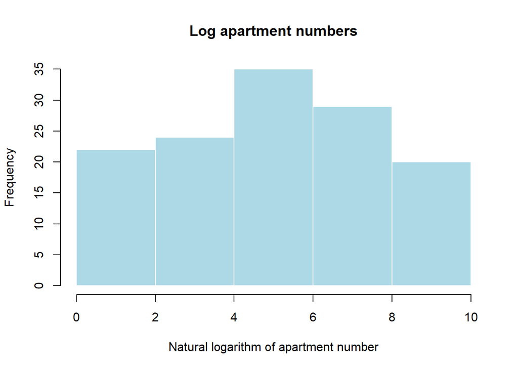

```r
hist(
  log(positive_apartment),
  breaks = "FD",
  col = "lightblue",
  border = "white",
  main = "Log apartment numbers",
  xlab = "Natural logarithm of apartment number"
)
```

I extracted 130 positive apartment numbers from the ends of addresses and plotted their natural logarithms. The histogram has its highest frequency between 4 and 6, with fewer observations toward either end. Addresses without a trailing number and nonpositive values are excluded.

### (f) Benford’s law

```r
leading_digit <- as.integer(
  substr(as.character(positive_apartment), 1, 1)
)

observed <- table(factor(leading_digit, levels = 1:9))
benford_prob <- log10(1 + 1 / (1:9))

benford_table <- data.frame(
  digit = 1:9,
  observed_proportion = as.numeric(observed) / sum(observed),
  expected_proportion = benford_prob
)

knitr::kable(
  benford_table,
  digits = 4,
  row.names = FALSE
)
```

| digit | observed_proportion | expected_proportion |
| --- | --- | --- |
| 1 | 0.0923 | 0.3010 |
| 2 | 0.1462 | 0.1761 |
| 3 | 0.1231 | 0.1249 |
| 4 | 0.1000 | 0.0969 |
| 5 | 0.1077 | 0.0792 |
| 6 | 0.1385 | 0.0669 |
| 7 | 0.0615 | 0.0580 |
| 8 | 0.0846 | 0.0512 |
| 9 | 0.1462 | 0.0458 |

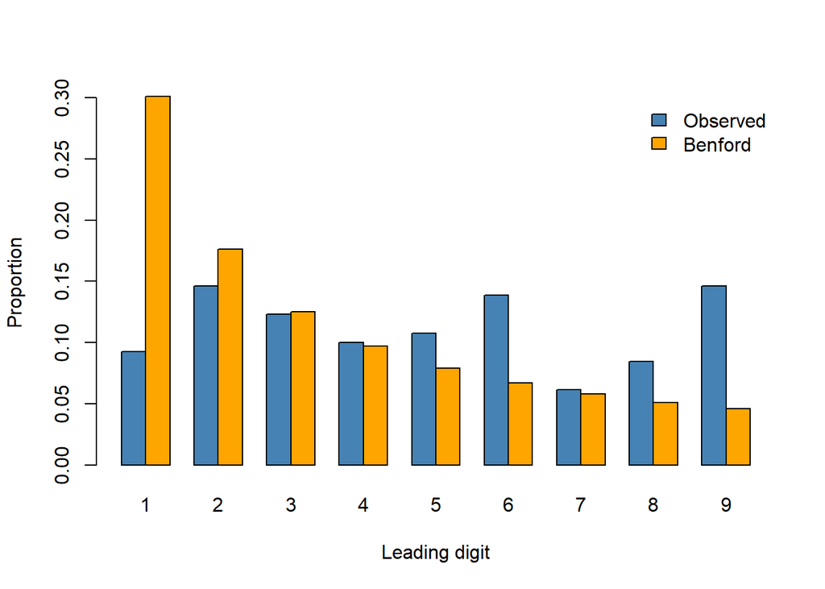

```r
barplot(
  rbind(benford_table$observed_proportion, benford_prob),
  beside = TRUE,
  names.arg = 1:9,
  col = c("steelblue", "orange"),
  legend.text = c("Observed", "Benford"),
  args.legend = list(x = "topright", bty = "n"),
  xlab = "Leading digit",
  ylab = "Proportion"
)
```

```r
benford_test <- chisq.test(observed, p = benford_prob)
benford_test
```

```
    Chi-squared test for given probabilities

data:  observed
X-squared = 62.268, df = 8, p-value = 1.67e-10
```

The apartment numbers do not appear to follow Benford’s law. The digit 1 occurs in only 9.23% of the numbers, compared with the expected 30.10%, while digit 9 occurs in 14.62%, compared with 4.58%. A chi-squared goodness-of-fit test gives $\chi^2(8) = 62.268$, $p = 1.67 \times 10^{-10}$, so I reject the null hypothesis that the leading digits follow Benford’s distribution. These numbers would therefore fail a Benford-based screening. However, apartment numbers are assigned identifiers and may not follow Benford’s law even in real data, so this result alone does not prove that they are artificial. In this case, the data source explicitly identifies the records as synthetic.

## Sources and assistance

Assignment: https://phuongov.github.io/stats506-f26/Homework%203/hw03.html - NHANES data and codebooks: https://wwwn.cdc.gov/nchs/nhanes/ - Sakila database: https://github.com/bradleygrant/sakila-sqlite3 - Australian sample data: https://www.briandunning.com/sample-data/ - Codex assisted with drafting part of R code, debugging, and reviewing results.